# PML-2

2023-07-29

title: “Practical Machine Learning Prediction Assignment”

## Introduction

This paper discusses how I created a model to characterize activity based on wearable data. All of the models in this document are created via the caret package.

```r
library(caret)
```

```r
library(lattice)
library(ggplot2)
```

## Data Aquisition and Preprocessing

There are initial two sets of data:  
* training  
* testing

Here I download the data sets:

```r
training <- read.csv("pml-training.csv", stringsAsFactors=FALSE, na.strings = c("", "#DIV/0", "NA"))
testing <- read.csv("pml-testing.csv", stringsAsFactors=FALSE, na.strings = c("", "#DIV/0", "NA"))
```

With the data on hand, there are two issues with the training data:  
* NA’s throughout  
* first seven columns are arbitrary

Here, I clean the data by:  
* Remove the columns with NA’s  
* Remove columns 1:7  
* Check for variables with Near Zero Variance in the remaining data  
+ There were none; none remained

```r
### Clean the data
training_clean <- training[, colSums(is.na(training)) == 0]
testing_clean <- testing[, colSums(is.na(training)) == 0]

### Remove columns 1-7
training_clean <- training_clean[-c(1:7)]
testing_clean <- testing_clean[-c(1:7)]


### Check for near zero variance
nearZeroVar(training_clean)
```

```
## integer(0)
```

### Model Consideration and Testing

In selecting a model, I considered three different models:  
* rpart  
* k nearest neighbors  
* Random Forest

To test the model validity I partitioned the training data into a train and test set. For each model, the test set was used to judge the accuracy.

```r
### Partition data

set.seed(3456)
inTrain <- createDataPartition(training_clean$classe, p=0.7, list=FALSE)
training_clean_train <- training_clean[inTrain, ]
training_clean_test <- training_clean[-inTrain, ]
```

For each model considered, a model is created using the training_clean_train data and then tested with the training_clean_test data.

Of course for the prediction portion of the assignment, I will select the RF model.

By calling the final model of the rf model we get the OOB estimate for the error rate: OOB estimate of error rate: 0.71%

The models were cross validated via the data partitioning, and also as part of the optimization and internal selection that occurs within the caret package.

Here I create the three models. After the RF model is completed, I call the finalModel to determine the OOB error rate.

```r
### rpart
m_rpart <- train(classe ~ ., data = training_clean_train, method = "rpart")
m_rpart
```

```
## CART
##
## 13737 samples
##    52 predictor
##     5 classes: 'A', 'B', 'C', 'D', 'E'
##
## No pre-processing
## Resampling: Bootstrapped (25 reps)
## Summary of sample sizes: 13737, 13737, 13737, 13737, 13737, 13737, ...
## Resampling results across tuning parameters:
##
##   cp          Accuracy   Kappa
##   0.03549995  0.5136790  0.3707044
##   0.06086190  0.4153542  0.2085181
##   0.11209440  0.3216105  0.0575868
##
## Accuracy was used to select the optimal model using the largest value.
## The final value used for the model was cp = 0.03549995.
```

```r
m_rpart$finalModel
```

```
## n= 13737
##
## node), split, n, loss, yval, (yprob)
##       * denotes terminal node
##
##  1) root 13737 9831 A (0.28 0.19 0.17 0.16 0.18)
##    2) roll_belt< 130.5 12613 8718 A (0.31 0.21 0.19 0.18 0.11)
##      4) pitch_forearm< -33.65 1118    9 A (0.99 0.0081 0 0 0) *
##      5) pitch_forearm>=-33.65 11495 8709 A (0.24 0.23 0.21 0.2 0.12)
##       10) magnet_dumbbell_y< 438.5 9671 6945 A (0.28 0.18 0.24 0.19 0.11)
##         20) roll_forearm< 123.5 6040 3582 A (0.41 0.18 0.19 0.16 0.063) *
##         21) roll_forearm>=123.5 3631 2431 C (0.074 0.18 0.33 0.23 0.19) *
##       11) magnet_dumbbell_y>=438.5 1824  901 B (0.033 0.51 0.041 0.23 0.19) *
##    3) roll_belt>=130.5 1124   11 E (0.0098 0 0 0 0.99) *
```

```r
test_output <- predict(m_rpart, training_clean_test[, -53])
mean(training_clean_test[, 53] == test_output)
```

```
## [1] 0.4971963
```

```r
table(training_clean_test[, 53], test_output)
```

```
##    test_output
##        A    B    C    D    E
##   A 1511   27  133    0    3
##   B  486  370  283    0    0
##   C  465   34  527    0    0
##   D  451  149  364    0    0
##   E  143  147  274    0  518
```

```r
### knn
m_knn <- train(classe ~ ., data = training_clean_train, method = "knn")
m_knn
```

```
## k-Nearest Neighbors
##
## 13737 samples
##    52 predictor
##     5 classes: 'A', 'B', 'C', 'D', 'E'
##
## No pre-processing
## Resampling: Bootstrapped (25 reps)
## Summary of sample sizes: 13737, 13737, 13737, 13737, 13737, 13737, ...
## Resampling results across tuning parameters:
##
##   k  Accuracy   Kappa
##   5  0.8671714  0.8319966
##   7  0.8503035  0.8106267
##   9  0.8362614  0.7928487
##
## Accuracy was used to select the optimal model using the largest value.
## The final value used for the model was k = 5.
```

```r
m_knn$finalModel
```

```
## 5-nearest neighbor model
## Training set outcome distribution:
##
##    A    B    C    D    E
## 3906 2658 2396 2252 2525
```

```r
test_output <- predict(m_knn, training_clean_test[, -53])
mean(training_clean_test[, 53] == test_output)
```

```
## [1] 0.9114698
```

```r
table(training_clean_test[, 53], test_output)
```

```
##    test_output
##        A    B    C    D    E
##   A 1602   18   13   35    6
##   B   60  989   44   24   22
##   C   18   41  941   14   12
##   D   13    7   72  865    7
##   E   14   43   29   29  967
```

```r
### rf
m_rf <- train(classe ~ ., data = training_clean_train, method = "rf")
m_rf
```

```
## Random Forest
##
## 13737 samples
##    52 predictor
##     5 classes: 'A', 'B', 'C', 'D', 'E'
##
## No pre-processing
## Resampling: Bootstrapped (25 reps)
## Summary of sample sizes: 13737, 13737, 13737, 13737, 13737, 13737, ...
## Resampling results across tuning parameters:
##
##   mtry  Accuracy   Kappa
##    2    0.9881983  0.9850538
##   27    0.9882662  0.9851412
##   52    0.9795328  0.9740812
##
## Accuracy was used to select the optimal model using the largest value.
## The final value used for the model was mtry = 27.
```

```r
m_rf$finalModel
```

```
##
## Call:
##  randomForest(x = x, y = y, mtry = param$mtry)
##                Type of random forest: classification
##                      Number of trees: 500
## No. of variables tried at each split: 27
##
##         OOB estimate of  error rate: 0.71%
## Confusion matrix:
##      A    B    C    D    E class.error
## A 3902    2    1    0    1 0.001024066
## B   23 2625   10    0    0 0.012415350
## C    0   11 2377    8    0 0.007929883
## D    0    0   24 2228    0 0.010657194
## E    0    1    9    7 2508 0.006732673
```

```r
test_output <- predict(m_rf, training_clean_test[, -53])
mean(training_clean_test[, 53] == test_output)
```

```
## [1] 0.9949023
```

```r
table(training_clean_test[, 53], test_output)
```

```
##    test_output
##        A    B    C    D    E
##   A 1674    0    0    0    0
##   B    9 1129    1    0    0
##   C    0    3 1017    6    0
##   D    0    0    8  954    2
##   E    0    0    1    0 1081
```

Here, I call the final model to see what are the most important variables in the RF model.

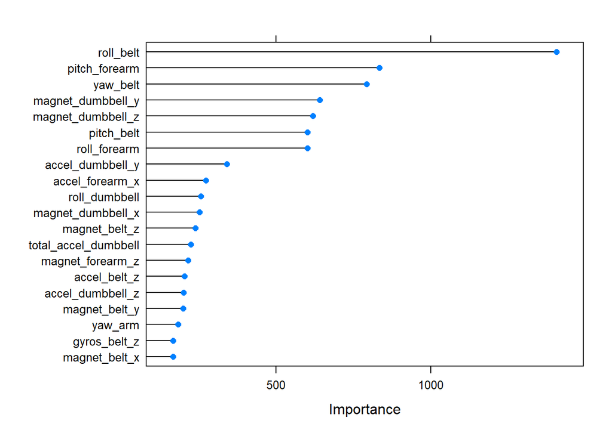

```r
tmp_2 <- m_rf$finalModel
rfImp <- varImp(m_rf, scale = FALSE)
plot(rfImp, top = 20)
```

Here, I create a data frame to compile the predictions of the three models to compare their output for the final 20 row Test set.

```r
N <- 20
compiled_results <- data.frame(
  id = numeric(N),
  rpart = character(N),
  knn = character(N),
  rf = character(N))

compiled_results$id <- 1:20
test_output_final <- predict(m_rpart, testing_clean[, -53])
compiled_results$rpart <- test_output_final
test_output_final <- predict(m_knn, testing_clean[, -53])
compiled_results$knn <- test_output_final
test_output_final <- predict(m_rf, testing_clean[, -53])
compiled_results$rf <- test_output_final

compiled_results
```

```
##    id rpart knn rf
## 1   1     C   B  B
## 2   2     A   A  A
## 3   3     C   B  B
## 4   4     A   A  A
## 5   5     A   A  A
## 6   6     C   E  E
## 7   7     C   D  D
## 8   8     A   B  B
## 9   9     A   A  A
## 10 10     A   A  A
## 11 11     C   B  B
## 12 12     C   C  C
## 13 13     C   D  B
## 14 14     A   A  A
## 15 15     C   D  E
## 16 16     A   E  E
## 17 17     A   A  A
## 18 18     A   B  B
## 19 19     A   B  B
## 20 20     C   B  B
```

```r
write.table(compiled_results, "compiled_results.csv")
```